# Exploratory Data Analysis — Internet Addiction, Loneliness & Depression among Adolescents (Bangladesh)

Team

2026-06-12

# 1. Loading the data

Data source: Sultana et al., *“A data set exploring the link and associated factors of internet addiction, loneliness, and depression among adolescents in Bangladesh”*, Mendeley Data, V2 (doi: 10.17632/yzcwfyrxy2.2). The dataset contains survey responses from **819 adolescents** (ages 13–19) with **91 variables**, including three validated psychometric instruments:

- **IAT** — Young’s Internet Addiction Test (20 items, `IAT1`–`IAT20`, total `TotalIA`, category `IAC`)
- **PHQ-9** — Patient Health Questionnaire for depression (9 items, `phq1`–`phq9`, total `totalphq`, category `categoryphq`)
- **UCLA Loneliness Scale** — (20 items, `loneliness1`–`loneliness20`, total `lonelinesstotal`)

```r
df <- read_excel("data/new_data.xlsx")
dim(df)
```

```
## [1] 819  91
```

```r
# Missing values check — the dataset is complete
sum(is.na(df))
```

```
## [1] 0
```

# 2. Variable overview

```r
# Summary of aggregate numeric variables only: mean, sd, min, max.
# Item-level columns (IAT1-20, phq1-9, loneliness1-20) are excluded — they
# only carry meaning aggregated into the totals below.
df %>%
  select(age, TotalIA, IAC, totalphq, categoryphq,
         lonelinesstotal, loneliness, Lonelinesscategory) %>%
  pivot_longer(everything(), names_to = "Variable", values_to = "value") %>%
  group_by(Variable) %>%
  summarise(Mean = round(mean(value), 2),
            SD   = round(sd(value), 2),
            Min  = min(value),
            Max  = max(value),
            .groups = "drop") %>%
  knitr::kable(caption = "Summary of aggregate numeric variables")
```

Summary of aggregate numeric variables

| Variable | Mean | SD | Min | Max |
| --- | --- | --- | --- | --- |
| IAC | 1.35 | 0.66 | 1 | 4 |
| Lonelinesscategory | 1.91 | 0.51 | 1 | 4 |
| TotalIA | 20.46 | 18.63 | 0 | 94 |
| age | 15.80 | 1.49 | 13 | 19 |
| categoryphq | 2.26 | 1.12 | 1 | 5 |
| loneliness | 2.57 | 0.50 | 2 | 3 |
| lonelinesstotal | 45.74 | 8.06 | 29 | 75 |
| totalphq | 8.33 | 5.73 | 0 | 27 |

```r
# Group the 91 columns into logical families for easier reading
demo_vars      <- c("age", "gender", "class", "group", "mothereducation",
                    "fathereducation", "livewith")
lifestyle_vars <- c("sleeptime", "studytime", "exercise", "hobbies", "smoker",
                    "sports", "activity", "studybook", "remainbusy", "bullied",
                    "parentarelationship", "friendsrelationship")
digital_vars   <- c("mainpurposeofInternetuse", "Whichdevice", "usingphone",
                    "keeingphone", "mediaapps", "socialmediatime",
                    "socialmediaisunsmart", "playinternetgame", "internettime",
                    "device", "anime", "facebook", "tiktok", "instragram",
                    "youtube", "watchingvideo")
scale_totals   <- c("TotalIA", "IAC", "totalphq", "categoryphq",
                    "lonelinesstotal", "Lonelinesscategory")

glimpse(df %>% select(all_of(c(demo_vars, lifestyle_vars, digital_vars, scale_totals))))
```

```
## Rows: 819
## Columns: 41
## $ age                      <dbl> 17, 16, 18, 18, 17, 19, 18, 18, 17, 16, 18, 1…
## $ gender                   <chr> "Female", "Male", "Female", "Male", "Male", "…
## $ class                    <chr> "Class- 11", "Class- 10", "Class- 9", "Class-…
## $ group                    <chr> "Commerce", "Arts", "Science", "Science", "Ar…
## $ mothereducation          <chr> "Upto college level", "Upto school level", "U…
## $ fathereducation          <chr> "Upto college level", "Upto school level", "U…
## $ livewith                 <chr> "with family", "with family", "with family", …
## $ sleeptime                <chr> "More than 7 hours", "6-7 hours", "6-7 hours"…
## $ studytime                <chr> "4-5 hours", "3-4 hours", "4-5 hours", "4-5 h…
## $ exercise                 <chr> "Yes", "No", "No", "No", "No", "No", "No", "N…
## $ hobbies                  <chr> "Yes", "Yes", "Yes", "Yes", "No", "Yes", "No"…
## $ smoker                   <chr> "No", "No", "No", "No", "No", "No", "No", "No…
## $ sports                   <chr> "No", "Yes", "No", "Yes", "Yes", "Yes", "No",…
```

[output cut: 28 more lines]

# 3. Codebook — categorical variables and their coding

The table below lists, for every categorical variable, the **original response options exactly as written in the data**, the **numeric code we assign** (factor level order: for binary variables No = 0 / Yes = 1; for ordinal variables 1 = lowest level), and the count of each option.

```r
# Explicit ordinal orderings (level 1 = first in the vector)
ordinal_levels <- list(
  class           = c("Class -8", "Class- 9", "Class- 10", "Class- 11", "Class - 12"),
  mothereducation = c("Upto school level", "Upto college level", "University", "I don't know"),
  fathereducation = c("Upto school level", "Upto college level", "University", "I don't know"),
  sleeptime       = c("Less than 6 hours", "5-6 hours", "6-7 hours", "More than 7 hours"),
  studytime       = c("Less than 3 hours", "3-4 hours", "4-5 hours", "More than 5 hours"),
  mediaapps       = c("Less Than 6 months", "6 months - 1 year", "1-2 years", "more than 2 years"),
  socialmediatime = c("Less than 1 hour", "1-2 hours", "2-3 hours", "3-4 hours", "More than 4 hours"),
  internettime    = c("Less than 1 hour", "1-2 hours", "2-3 hours", "3-4 hours", "More than 4 hours"),
  friendsrelationship = c("Not good", "Average", "Good"),
  parentarelationship = c("Average", "Good")
)

binary_vars <- c("usingphone", "keeingphone", "socialmediaisunsmart", "playinternetgame",
                 "exercise", "hobbies", "device", "smoker", "anime", "facebook", "tiktok",
                 "instragram", "youtube", "watchingvideo", "sports", "studybook",
                 "remainbusy", "bullied")

nominal_vars <- c("gender", "group", "livewith", "mainpurposeofInternetuse",
                  "Whichdevice", "activity")

# Apply the coding to the data frame
df <- df %>%
  mutate(across(all_of(names(ordinal_levels)),
                ~ factor(.x, levels = ordinal_levels[[cur_column()]], ordered = TRUE)),
         across(all_of(binary_vars), ~ factor(.x, levels = c("No", "Yes"))),
         across(all_of(nominal_vars), as.factor))
```

```r
# Build the codebook with base R only, to avoid any factor-type clashes when
# binding rows from variables that have different factor level sets.
build_codebook_rows <- function(v) {
  x   <- df[[v]]
  tab <- table(x)                                  # named integer vector
  opt <- as.character(names(tab))                  # original labels as character
  n   <- as.integer(unname(tab))

  if (is.factor(x)) {
    code <- match(opt, levels(x))                  # 1..k in declared order
  } else {
    code <- seq_along(opt)
  }
  if (v %in% binary_vars) code <- code - 1L        # No = 0, Yes = 1

  data.frame(
    variable = v,
    code     = as.integer(code),
    option   = opt,
    n        = n,
    stringsAsFactors = FALSE
  )[order(code), ]
}

codebook <- do.call(
  rbind,
  lapply(c(names(ordinal_levels), binary_vars, nominal_vars),
         build_codebook_rows)
)
rownames(codebook) <- NULL

knitr::kable(codebook,
             col.names = c("Variable", "Numeric code",
                           "Original option (as in data)", "n"),
             caption = "Codebook: original response options and assigned numeric codes")
```

Codebook: original response options and assigned numeric codes

| Variable | Numeric code | Original option (as in data) | n |
| --- | --- | --- | --- |
| class | 1 | Class -8 | 40 |
| class | 2 | Class- 9 | 316 |
| class | 3 | Class- 10 | 332 |
| class | 4 | Class- 11 | 86 |
| class | 5 | Class - 12 | 45 |
| mothereducation | 1 | Upto school level | 387 |
| mothereducation | 2 | Upto college level | 140 |
| mothereducation | 3 | University | 123 |
| mothereducation | 4 | I don’t know | 169 |
| fathereducation | 1 | Upto school level | 301 |
| fathereducation | 2 | Upto college level | 145 |
| fathereducation | 3 | University | 185 |
| fathereducation | 4 | I don’t know | 188 |
| sleeptime | 1 | Less than 6 hours | 115 |
| sleeptime | 2 | 5-6 hours | 183 |
| sleeptime | 3 | 6-7 hours | 313 |
| sleeptime | 4 | More than 7 hours | 208 |
| studytime | 1 | Less than 3 hours | 196 |
| studytime | 2 | 3-4 hours | 264 |
| studytime | 3 | 4-5 hours | 199 |
| studytime | 4 | More than 5 hours | 160 |
| mediaapps | 1 | Less Than 6 months | 360 |
| mediaapps | 2 | 6 months - 1 year | 130 |
| mediaapps | 3 | 1-2 years | 138 |
| mediaapps | 4 | more than 2 years | 191 |
| socialmediatime | 1 | Less than 1 hour | 507 |
| socialmediatime | 2 | 1-2 hours | 156 |
| socialmediatime | 3 | 2-3 hours | 71 |
| socialmediatime | 4 | 3-4 hours | 33 |
| socialmediatime | 5 | More than 4 hours | 52 |

[output cut: 69 more lines]

```r
# Coding of the psychometric category variables (already numeric in the raw data)
tribble(
  ~Variable, ~Code, ~Meaning, ~n,
  "IAC", 1, "Normal / mild internet addiction",            613,
  "IAC", 2, "Moderate",                                    123,
  "IAC", 3, "Severe",                                       82,
  "IAC", 4, "(single extreme case)",                          1,
  "categoryphq", 1, "Minimal depression (PHQ 0-4)",        245,
  "categoryphq", 2, "Mild (5-9)",                          273,
  "categoryphq", 3, "Moderate (10-14)",                    176,
  "categoryphq", 4, "Moderately severe (15-19)",            91,
  "categoryphq", 5, "Severe (20-27)",                       34,
  "Lonelinesscategory", 1, "Low loneliness",               145,
  "Lonelinesscategory", 2, "Moderate",                     608,
  "Lonelinesscategory", 3, "Moderately high",               63,
  "Lonelinesscategory", 4, "High",                           3
) %>%
  knitr::kable(caption = "Psychometric category variables (numeric in the raw data)")
```

Psychometric category variables (numeric in the raw data)

| Variable | Code | Meaning | n |
| --- | --- | --- | --- |
| IAC | 1 | Normal / mild internet addiction | 613 |
| IAC | 2 | Moderate | 123 |
| IAC | 3 | Severe | 82 |
| IAC | 4 | (single extreme case) | 1 |
| categoryphq | 1 | Minimal depression (PHQ 0-4) | 245 |
| categoryphq | 2 | Mild (5-9) | 273 |
| categoryphq | 3 | Moderate (10-14) | 176 |
| categoryphq | 4 | Moderately severe (15-19) | 91 |
| categoryphq | 5 | Severe (20-27) | 34 |
| Lonelinesscategory | 1 | Low loneliness | 145 |
| Lonelinesscategory | 2 | Moderate | 608 |
| Lonelinesscategory | 3 | Moderately high | 63 |
| Lonelinesscategory | 4 | High | 3 |

# 4. Socio-demographics

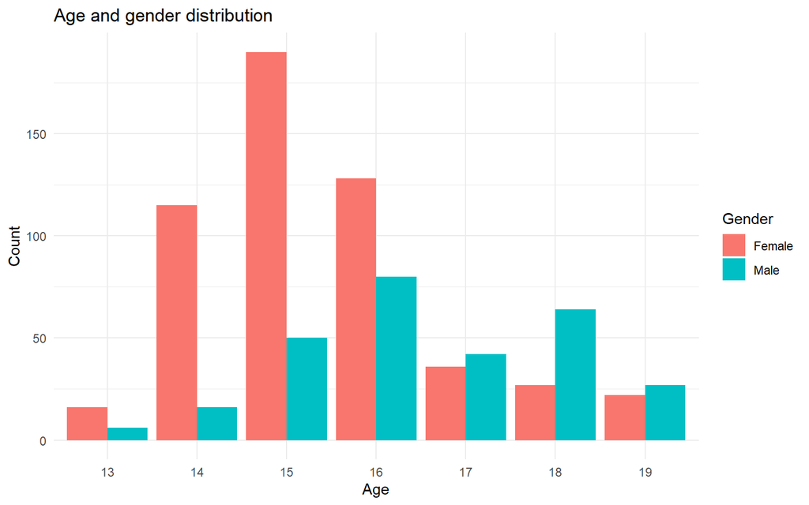

```r
df %>%
  count(age, gender) %>%
  ggplot(aes(x = factor(age), y = n, fill = gender)) +
  geom_col(position = "dodge") +
  labs(title = "Age and gender distribution",
       x = "Age", y = "Count", fill = "Gender") +
  theme_minimal()
```

```r
df %>% count(gender) %>% mutate(pct = percent(n / sum(n)))
```

```
## # A tibble: 2 × 3
##   gender     n pct
##   <fct>  <int> <chr>
## 1 Female   534 65%
## 2 Male     285 35%
```

```r
df %>% count(livewith) %>% mutate(pct = percent(n / sum(n)))
```

```
## # A tibble: 4 × 3
##   livewith                  n pct
##   <fct>                 <int> <chr>
## 1 School/College Hostel     5 0.6%
## 2 with family             767 93.7%
## 3 with friends             19 2.3%
## 4 With relatives           28 3.4%
```

```r
df %>% count(class) %>% mutate(pct = percent(n / sum(n)))
```

```
## # A tibble: 5 × 3
##   class          n pct
##   <ord>      <int> <chr>
## 1 Class -8      40 4.88%
## 2 Class- 9     316 38.58%
## 3 Class- 10    332 40.54%
## 4 Class- 11     86 10.50%
## 5 Class - 12    45 5.49%
```

The sample skews female (~65%) and the vast majority live with family. This is relevant for the “is the sample representative?” question raised in the proposal feedback.

# 5. Digital behavior patterns

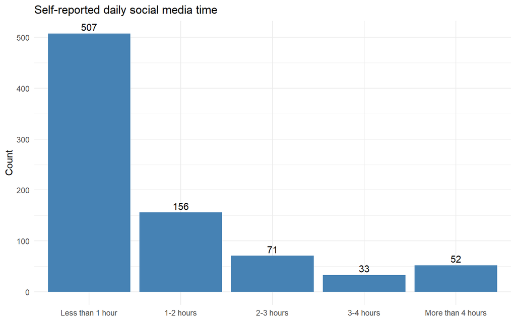

```r
df %>%
  count(socialmediatime) %>%
  ggplot(aes(x = socialmediatime, y = n)) +
  geom_col(fill = "steelblue") +
  geom_text(aes(label = n), vjust = -0.4) +
  labs(title = "Self-reported daily social media time",
       x = NULL, y = "Count") +
  theme_minimal()
```

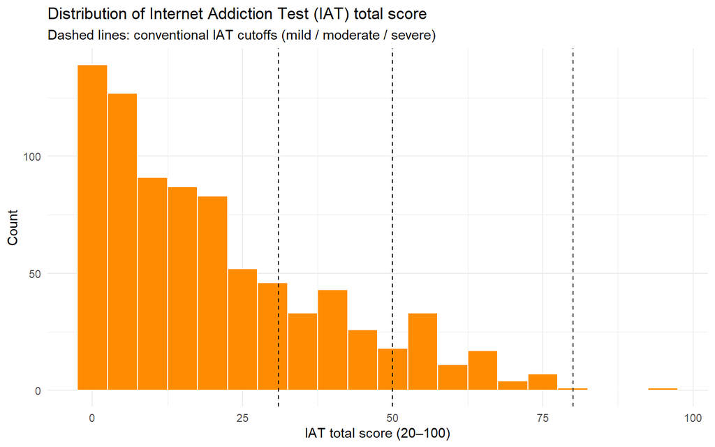

```r
ggplot(df, aes(x = TotalIA)) +
  geom_histogram(binwidth = 5, fill = "darkorange", color = "white") +
  geom_vline(xintercept = c(31, 50, 80), linetype = "dashed") +
  labs(title = "Distribution of Internet Addiction Test (IAT) total score",
       subtitle = "Dashed lines: conventional IAT cutoffs (mild / moderate / severe)",
       x = "IAT total score (20–100)", y = "Count") +
  theme_minimal()
```

```r
df %>%
  count(IAC) %>%
  mutate(category = c("Normal/Mild", "Moderate", "Severe", "Very severe")[IAC],
         pct = percent(n / sum(n)))
```

```
## # A tibble: 4 × 4
##     IAC     n category    pct
##   <dbl> <int> <chr>       <chr>
## 1     1   613 Normal/Mild 74.8%
## 2     2   123 Moderate    15.0%
## 3     3    82 Severe      10.0%
## 4     4     1 Very severe 0.1%
```

# 6. Mental health outcomes

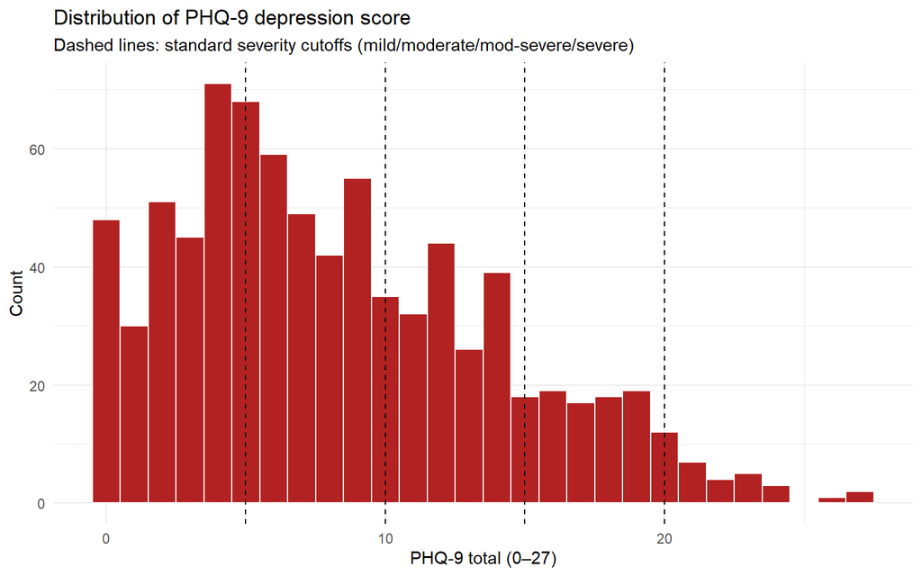

```r
ggplot(df, aes(x = totalphq)) +
  geom_histogram(binwidth = 1, fill = "firebrick", color = "white") +
  geom_vline(xintercept = c(5, 10, 15, 20), linetype = "dashed") +
  labs(title = "Distribution of PHQ-9 depression score",
       subtitle = "Dashed lines: standard severity cutoffs (mild/moderate/mod-severe/severe)",
       x = "PHQ-9 total (0–27)", y = "Count") +
  theme_minimal()
```

```r
# Candidate binary labels for the predictive question
tibble(
  cutoff = c("PHQ-9 >= 10 (moderate+)", "PHQ-9 >= 15 (mod-severe+)"),
  positives = c(sum(df$totalphq >= 10), sum(df$totalphq >= 15)),
  pct = percent(c(mean(df$totalphq >= 10), mean(df$totalphq >= 15)))
)
```

```
## # A tibble: 2 × 3
##   cutoff                    positives pct
##   <chr>                         <int> <chr>
## 1 PHQ-9 >= 10 (moderate+)         301 37%
## 2 PHQ-9 >= 15 (mod-severe+)       125 15%
```

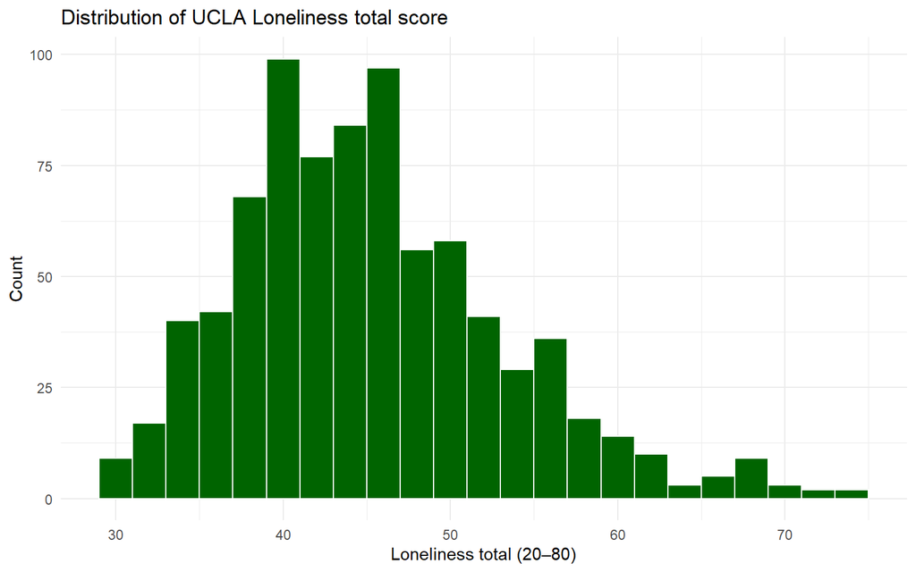

```r
ggplot(df, aes(x = lonelinesstotal)) +
  geom_histogram(binwidth = 2, fill = "darkgreen", color = "white") +
  labs(title = "Distribution of UCLA Loneliness total score",
       x = "Loneliness total (20–80)", y = "Count") +
  theme_minimal()
```

# 7. Preliminary relationships

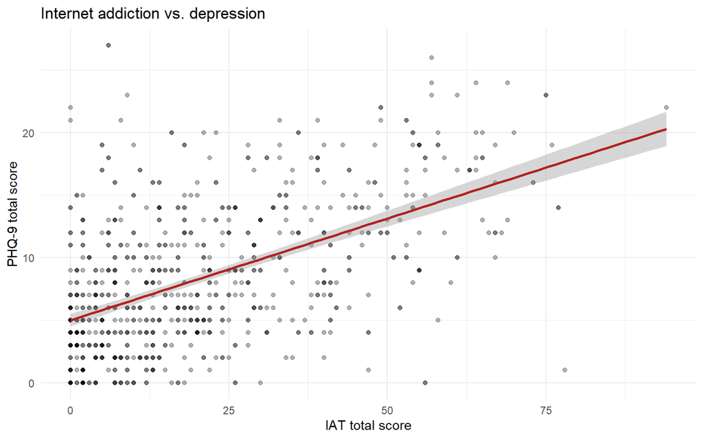

```r
ggplot(df, aes(x = TotalIA, y = totalphq)) +
  geom_point(alpha = 0.3) +
  geom_smooth(method = "lm", color = "firebrick") +
  labs(title = "Internet addiction vs. depression",
       x = "IAT total score", y = "PHQ-9 total score") +
  theme_minimal()
```

```r
df %>%
  select(TotalIA, totalphq, lonelinesstotal, age) %>%
  cor() %>%
  round(2)
```

```
##                 TotalIA totalphq lonelinesstotal  age
## TotalIA            1.00     0.53            0.31 0.26
## totalphq           0.53     1.00            0.37 0.21
## lonelinesstotal    0.31     0.37            1.00 0.09
## age                0.26     0.21            0.09 1.00
```

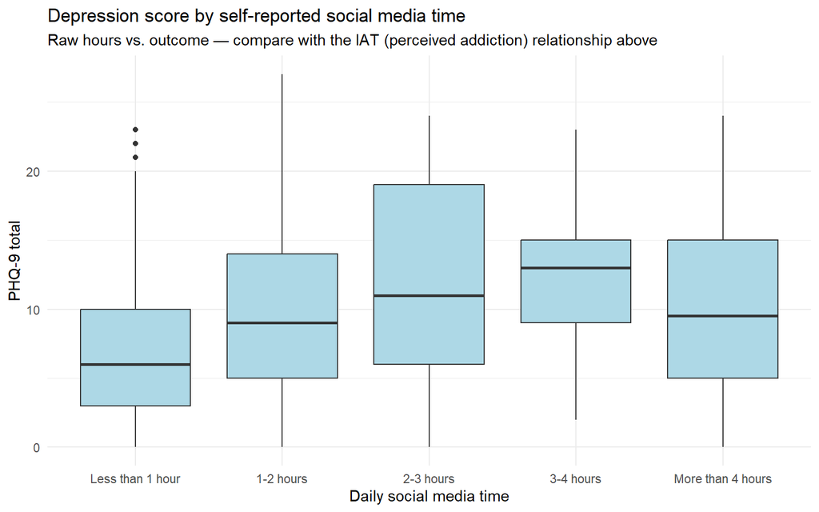

```r
ggplot(df, aes(x = socialmediatime, y = totalphq)) +
  geom_boxplot(fill = "lightblue") +
  labs(title = "Depression score by self-reported social media time",
       subtitle = "Raw hours vs. outcome — compare with the IAT (perceived addiction) relationship above",
       x = "Daily social media time", y = "PHQ-9 total") +
  theme_minimal()
```

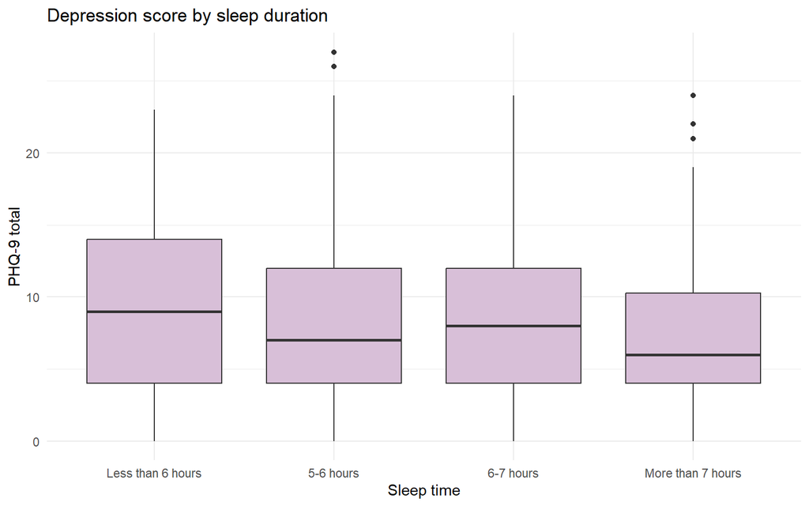

```r
ggplot(df, aes(x = sleeptime, y = totalphq)) +
  geom_boxplot(fill = "thistle") +
  labs(title = "Depression score by sleep duration",
       x = "Sleep time", y = "PHQ-9 total") +
  theme_minimal()
```

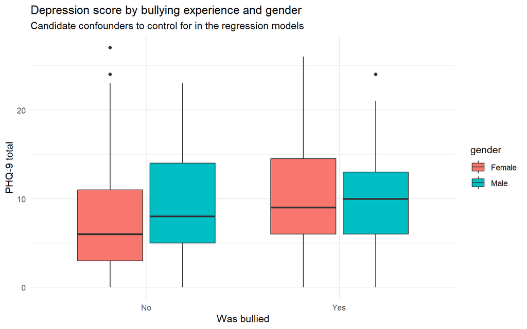

```r
df %>%
  ggplot(aes(x = bullied, y = totalphq, fill = gender)) +
  geom_boxplot() +
  labs(title = "Depression score by bullying experience and gender",
       subtitle = "Candidate confounders to control for in the regression models",
       x = "Was bullied", y = "PHQ-9 total") +
  theme_minimal()
```

# 8. Notes for the work plan

- **Outcome (Y):** `totalphq` (continuous, for the exploratory linear regressions) and a binary depression label derived from a standard PHQ-9 cutoff (for the predictive question). With a PHQ-9 ≥ 10 cutoff, ~37% of the sample is positive — the class imbalance problem from the previous dataset is largely resolved.
- **Predictors (X):** digital behavior family (`socialmediatime`, `internettime`, `TotalIA`, platform indicators), controlling for socio-demographics (`age`, `gender`, parental education, `livewith`) and lifestyle (`sleeptime`, `exercise`, `bullied`, `parentarelationship`, `friendsrelationship`, `smoker`).
- **Key contrast for the exploratory question:** raw self-reported time (`socialmediatime`/`internettime`) vs. perceived addiction (`TotalIA`) as competing predictors of the same outcome.
- All three psychological scales (IAT, PHQ-9, UCLA) are validated, widely used instruments — items are available individually, so internal consistency (Cronbach’s alpha) can be computed and reported.

# Appendix: data/README.md

# Data README — Internet Addiction, Loneliness & Depression among Adolescents in Bangladesh

## Source

Sultana, Mst. Sabrina; Islam, Md. Saiful; et al., *“A data set exploring the link and associated factors of internet addiction, loneliness, and depression among adolescents in Bangladesh”*, **Mendeley Data, V2**. DOI: [10.17632/yzcwfyrxy2.2](https://data.mendeley.com/datasets/yzcwfyrxy2/2)

The data come from a cross-sectional survey of **819 adolescents (ages 13–19)** attending school/college in Bangladesh. Each row is one respondent. The file contains **91 variables** and **no missing values**.

The dataset combines:

1. **Socio-demographic variables** (7)
2. **Lifestyle & social variables** (12)
3. **Digital-behavior variables** (16)
4. **Three validated psychometric instruments** with item-level responses and computed totals/categories:
   - **IAT** — Young’s Internet Addiction Test (20 items)
   - **PHQ-9** — Patient Health Questionnaire, depression module (9 items)
   - **UCLA Loneliness Scale (Version 3)** (20 items)

## 1. Socio-demographic variables

| Variable | Type | Values (as written in the data) |
| --- | --- | --- |
| `age` | integer | 13–19 (years) |
| `gender` | categorical | `Female` (534) / `Male` (285) |
| `class` | ordinal | `Class -8` (40), `Class- 9` (316), `Class- 10` (332), `Class- 11` (86), `Class - 12` (45). Note: inconsistent spacing/hyphens in the raw strings. |
| `group` | categorical | `Science` (402) / `Arts` (348) / `Commerce` (69) — academic track |
| `mothereducation` | ordinal | `Upto school level` (387), `Upto college level` (140), `University` (123), `I don't know` (169) |
| `fathereducation` | ordinal | `Upto school level` (301), `Upto college level` (145), `University` (185), `I don't know` (188) |
| `livewith` | categorical | `with family` (767), `With relatives` (28), `with friends` (19), `School/College Hostel` (5) |

## 2. Lifestyle & social variables

| Variable | Type | Values |
| --- | --- | --- |
| `sleeptime` | ordinal | `Less than 6 hours` (115) < `5-6 hours` (183) < `6-7 hours` (313) < `More than 7 hours` (208). Note: the first two categories overlap in the original wording. |
| `studytime` | ordinal | `Less than 3 hours` (196) < `3-4 hours` (264) < `4-5 hours` (199) < `More than 5 hours` (160) — daily study hours |
| `exercise` | binary | `Yes` (434) / `No` (385) — exercises regularly |
| `hobbies` | binary | `Yes` (530) / `No` (289) — has hobbies |
| `sports` | binary | `Yes` (272) / `No` (547) — plays sports |
| `activity` | categorical | Main leisure activity: `Hanging around` (291), `Playing` (158), `Sleeping` (147), `Others` (129), `Using Mobile Phone` (71), `Gaming` (23) |
| `studybook` | binary | `Yes` (480) / `No` (339) — reads books beyond studies |
| `remainbusy` | binary | `Yes` (457) / `No` (362) — generally remains busy |
| `smoker` | binary | `Yes` (30) / `No` (789) |
| `bullied` | binary | `Yes` (150) / `No` (669) — has been bullied |
| `parentarelationship` | ordinal | `Good` (777) / `Average` (42) — relationship with parents |
| `friendsrelationship` | ordinal | `Good` (713) / `Average` (100) / `Not good` (6) — relationship with friends |

## 3. Digital-behavior variables

| Variable | Type | Values |
| --- | --- | --- |
| `mainpurposeofInternetuse` | categorical | `Social networking` (370), `Study` (315), `Others` (66), `Gaming` (38), `Chatting` (30) |
| `Whichdevice` | categorical | `Mobile` (724), `Computer` (48), `Tab` (47) — main device for internet use |
| `usingphone` | binary | `Yes` (393) / `No` (426) — uses phone while studying |
| `keeingphone` | binary | `Yes` (578) / `No` (241) — keeps phone nearby while sleeping (“keeping phone”) |
| `mediaapps` | ordinal | Time since started using social media apps: `Less Than 6 months` (360) < `6 months - 1 year` (130) < `1-2 years` (138) < `more than 2 years` (191) |
| `socialmediatime` | ordinal | Daily social media hours: `Less than 1 hour` (507) < `1-2 hours` (156) < `2-3 hours` (71) < `3-4 hours` (33) < `More than 4 hours` (52) |
| `internettime` | ordinal | Daily non-social-media internet hours: `Less than 1 hour` (685) < `1-2 hours` (83) < `2-3 hours` (16) < `3-4 hours` (12) < `More than 4 hours` (23) |
| `socialmediaisunsmart` | binary | `Yes` (249) / `No` (570) — thinks not using social media is “unsmart” |
| `playinternetgame` | binary | `Yes` (252) / `No` (567) — plays online games |
| `device` | binary | `Yes` (327) / `No` (492) — owns a personal device |
| `anime` | binary | `Yes` (274) / `No` (545) — watches anime |
| `facebook` | binary | `Yes` (360) / `No` (459) — uses Facebook |
| `tiktok` | binary | `Yes` (265) / `No` (554) — uses TikTok |
| `instragram` | binary | `Yes` (280) / `No` (539) — uses Instagram (note the typo in the column name) |
| `youtube` | binary | `Yes` (689) / `No` (130) — uses YouTube |
| `watchingvideo` | binary | `Yes` (200) / `No` (619) — main use is watching videos |

> Binary variables are coded in our analysis as **No = 0, Yes = 1** (R factor with “No” as the reference level). Ordinal variables are ordered factors with the orderings shown above (lowest = 1).

## 4. Psychometric scales

### 4.1 Internet Addiction Test (IAT) — `IAT1` … `IAT20`, `TotalIA`, `IAC`

Young’s 20-item Internet Addiction Test (Young, 1998; copyright © Kimberly S. Young). Each item is rated on a 6-point Likert scale (**0 = Does not apply / Not at all**, **1 = Rarely**, **2 = Occasionally**, **3 = Frequently**, **4 = Often**, **5 = Always**), referring to the past month. Individual items (`IAT1`–`IAT20`) are not used directly in our analysis; we only use the validated aggregate `TotalIA` and the derived category `IAC`.

- `TotalIA` = sum of the 20 items, range 0–100 (observed: 0–94).
- `IAC` = internet addiction category derived from `TotalIA`:

[output not shown]

> The exact cutoffs used by the dataset authors should be verified against the Mendeley documentation; the table reflects the observed coding.

### 4.2 PHQ-9 (depression) — `phq1` … `phq9`, `totalphq`, `categoryphq`

Patient Health Questionnaire, 9-item depression module (Kroenke, Spitzer & Williams, 2001; public domain). Items refer to the **last 2 weeks** and are scored: **0 = Not at all**, **1 = Several days**, **2 = More than half the days**, **3 = Nearly every day**. Individual items (`phq1`–`phq9`) are not used directly in our analysis; we only use the validated aggregate `totalphq` and the derived category `categoryphq`.

- `totalphq` = sum of the 9 items, range 0–27.
- `categoryphq` = standard PHQ-9 severity category:

| Code | Severity | PHQ-9 range | n |
| --- | --- | --- | --- |
| 1 | Minimal | 0–4 | 245 |
| 2 | Mild | 5–9 | 273 |
| 3 | Moderate | 10–14 | 176 |
| 4 | Moderately severe | 15–19 | 91 |
| 5 | Severe | 20–27 | 34 |

A binary depression label using the standard clinical cutoff **PHQ-9 ≥ 10** yields 301 positives (36.8%).

### 4.3 UCLA Loneliness Scale (Version 3) — `loneliness1` … `loneliness20`, `lonelinesstotal`, `loneliness`, `Lonelinesscategory`

20-item loneliness scale (Russell, 1996; *Journal of Personality Assessment* 66(1), 20–40). Items are rated **1 = Never**, **2 = Rarely**, **3 = Sometimes**, **4 = Always/Often**. The official scoring reverse-codes items 1, 5, 6, 9, 10, 15, 16, 19, 20 before summing, so that a higher total always indicates more loneliness. Individual items (`loneliness1`–`loneliness20`) are not used directly in our analysis; we only use the validated aggregate `lonelinesstotal` and the derived category `Lonelinesscategory`.

> **Important — verify reverse coding in this dataset.** The `lonelinesstotal` column in the file should be checked: if the total was computed from raw answers without reverse-coding, it is **not** a valid loneliness score and should be recomputed. Run the sanity-check correlation in the analysis script before using it.
- `lonelinesstotal` = sum across the 20 items, theoretical range 20–80 (observed: 29–75).
- `loneliness` = coarse level (observed values 2–3).
- `Lonelinesscategory` = loneliness severity category:

| Code | Category | n |
| --- | --- | --- |
| 1 | Low | 145 |
| 2 | Moderate | 608 |
| 3 | Moderately high | 63 |
| 4 | High | 3 |

> As with the IAT, exact category cutoffs should be cross-checked with the dataset documentation on Mendeley.

## Known data-quality notes

- Column names contain typos inherited from the original survey: `keeingphone` (keeping phone), `instragram` (Instagram), `parentarelationship`.
- `class` strings have inconsistent spacing (`Class- 10` vs `Class - 12` vs `Class -8`) — normalize before treating as a factor.
- `sleeptime` categories `Less than 6 hours` and `5-6 hours` overlap verbally; we treat them as ordered as listed.
- All time variables (sleep, study, social media, internet) are **self-reported, binned categories**, not measured values — a limitation to acknowledge when interpreting effect sizes.
- The sample is a convenience sample skewed female (65%) and toward ages 14–16; representativeness of Bangladeshi adolescents in general is limited.